# Nanodegree de Inteligência Artificial

## Redes Neurais Convolucionais

## Project: Escreva um Algoritmo para um Aplicativo de Identificação de Cachorros

Neste caderno, alguns códigos de modelo já foram fornecidos para você e você precisará implementar funcionalidades adicionais para concluir com êxito este projeto. Você não precisará modificar o código incluído além do que é solicitado. As seções que começam com **'(IMPLEMENTATION)'** no cabeçalho indicam que o seguinte bloco de código exigirá uma funcionalidade adicional que você deve fornecer. Serão fornecidas instruções para cada seção e as especificidades da implementação serão marcadas no bloco de códigos com uma instrução 'TODO'. Por favor, leia atentamente as instruções!

Além de implementar o código, haverá perguntas que você deve responder relacionadas ao projeto e à sua implementação. Cada seção onde você responderá uma questão é precedida por um cabeçalho **'Question X'** . Leia atentamente cada pergunta e forneça respostas completas nas seguintes caixas de texto que começam com **'Resposta:'** . A submissão do seu projeto será avaliada com base nas suas respostas para cada uma das perguntas e na implementação que você fornecer.

> **Nota:** As células Code e Markdown podem ser executadas usando o atalho de teclado **Shift + Enter** . As células Markdown podem ser editadas clicando duas vezes na célula para entrar no modo de edição.

A rubrica contém *opcional* "Sugestões de destaque" para aprimorar o projeto além dos requisitos mínimos. Se você decidir seguir as "Sugestões de destaque", inclua o código neste bloco de notas do IPython.

### Porque estamos aqui

Neste caderno, você dará os primeiros passos para desenvolver um algoritmo que possa ser usado como parte de um aplicativo móvel ou da web. No final deste projeto, seu código aceitará qualquer imagem fornecida pelo usuário como entrada. Se um cachorro for detectado na imagem, ele fornecerá uma estimativa da raça do cão. Se um ser humano for detectado, ele fornecerá uma estimativa da raça do cão que mais se parece. A imagem abaixo mostra a saída de amostra potencial do seu projeto finalizado (... mas esperamos que o algoritmo de cada aluno se comporte de maneira diferente!).

[figure not shown]

Neste cenário do mundo real, você precisará juntar uma série de modelos para realizar diferentes tarefas; por exemplo, o algoritmo que detecta humanos em uma imagem será diferente da CNN que infere a raça do cão. Existem muitos pontos de possíveis falhas e nenhum algoritmo perfeito existe. Sua solução imperfeita, no entanto, criará uma experiência de usuário divertida!

### A estrada adiante

Nós quebramos o notebook em etapas separadas. Sinta-se à vontade para usar os links abaixo para navegar no notebook.

- Passo 0: importar conjuntos de dados
- Passo 1: Detectar Humanos
- Passo 2: Detectar Cães
- Passo 3: Crie uma CNN para classificar as raças de cães (do zero)
- Passo 4: Use uma CNN para Classificar Raças de Cães (usando o Aprendizado de Transferência)
- Passo 5: Crie uma CNN para Classificar Raças de Cães (usando Transfer Learning)
- Passo 6: Escreva seu Algoritmo
- Passo 7: Teste seu algoritmo

## Etapa 0: importar conjuntos de dados

### Importar conjunto de dados do cão

Na célula de código abaixo, importamos um conjunto de dados de imagens de cachorros. Nós preenchemos algumas variáveis através do uso da função `load_files` da biblioteca scikit-learn:

- `train_files`,`valid_files`, `test_files` - matrizes numpy contendo caminhos de arquivo para imagens
- `train_targets`,`valid_targets`, `test_targets` - matrizes numpy contendo rótulos de classificação codificados em onehot
- `dog_names` - lista de nomes de raças de cães com valores de string para traduzir rótulos

```python
from sklearn.datasets import load_files
from keras.utils import np_utils
import numpy as np
from glob import glob

# define function to load train, test, and validation datasets
def load_dataset(path):
    data = load_files(path)
    dog_files = np.array(data['filenames'])
    dog_targets = np_utils.to_categorical(np.array(data['target']), 133)
    return dog_files, dog_targets

# load train, test, and validation datasets
train_files, train_targets = load_dataset('dogImages/train')
valid_files, valid_targets = load_dataset('dogImages/valid')
test_files, test_targets = load_dataset('dogImages/test')

# load list of dog names
dog_names = [item[20:-1] for item in sorted(glob("dogImages/train/*/"))]

# print statistics about the dataset
print('There are %d total dog categories.' % len(dog_names))
print('There are %s total dog images.\n' % len(np.hstack([train_files, valid_files, test_files])))
print('There are %d training dog images.' % len(train_files))
print('There are %d validation dog images.' % len(valid_files))
print('There are %d test dog images.'% len(test_files))
```

```
There are 133 total dog categories.
There are 8351 total dog images.

There are 6680 training dog images.
There are 835 validation dog images.
There are 836 test dog images.
```

### Import DataSet

Na célula de código abaixo, nós importamos um conjunto de dados de imagens humanas, onde os caminhos de arquivo são armazenados no array numpy `human_files`.

```python
import random
random.seed(8675309)

# load filenames in shuffled human dataset
human_files = np.array(glob("lfw/*/*"))
random.shuffle(human_files)

# print statistics about the dataset
print('There are %d total human images.' % len(human_files))
```

```
There are 13233 total human images.
```

## Passo 1: Detectar Humanos

Usamos a implementação do OpenCV de [classificadores em cascata baseados em características do Haar] (http://docs.opencv.org/trunk/d7/d8b/tutorial_py_face_detection.html) para detectar rostos humanos em imagens. O OpenCV fornece muitos detectores de face pré-treinados, armazenados como arquivos XML no [github] (https://github.com/opencv/opencv/tree/master/data/haarcascades). Nós baixamos um desses detectores e o armazenamos no diretório `haarcascades`.

Na próxima célula de código, demonstramos como usar esse detector para encontrar rostos humanos em uma imagem de amostra.

```
Number of faces detected: 1
```

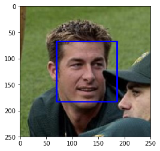

```python
import cv2
import matplotlib.pyplot as plt
%matplotlib inline

# extract pre-trained face detector
face_cascade = cv2.CascadeClassifier('haarcascades/haarcascade_frontalface_alt.xml')

# load color (BGR) image
img = cv2.imread(human_files[3000])
# convert BGR image to grayscale
gray = cv2.cvtColor(img, cv2.COLOR_BGR2GRAY)

# find faces in image
faces = face_cascade.detectMultiScale(gray)

# print number of faces detected in the image
print('Number of faces detected:', len(faces))

# get bounding box for each detected face
for (x,y,w,h) in faces:
    # add bounding box to color image
    cv2.rectangle(img,(x,y),(x+w,y+h),(255,0,0),2)

# convert BGR image to RGB for plotting
cv_rgb = cv2.cvtColor(img, cv2.COLOR_BGR2RGB)

# display the image, along with bounding box
plt.imshow(cv_rgb)
plt.show()
```

Antes de usar qualquer um dos detectores de face, é procedimento padrão converter as imagens em tons de cinza. A função `detectMultiScale` executa o classificador armazenado em`face_cascade` e pega a imagem em tons de cinza como um parâmetro.

No código acima, `faces` é um array numpy de faces detectadas, onde cada linha corresponde a uma face detectada. Cada face detectada é uma matriz 1D com quatro entradas que especifica a caixa delimitadora da face detectada. As duas primeiras entradas na matriz (extraídas no código acima como `x` e`y`) especificam as posições horizontal e vertical do canto superior esquerdo da caixa delimitadora. As duas últimas entradas na matriz (extraídas aqui como `w` e`h`) especificam a largura e a altura da caixa.

### Escreva um Detector de Rosto Humano

```python
# returns "True" if face is detected in image stored at img_path
def face_detector(img_path):
    img = cv2.imread(img_path)
    gray = cv2.cvtColor(img, cv2.COLOR_BGR2GRAY)
    faces = face_cascade.detectMultiScale(gray)
    return len(faces) > 0
```

### (IMPLEMENTATION) Avaliar o detector de rosto humano

**Questão 1:** Use a célula de código abaixo para testar o desempenho da função `face_detector`.

- Qual porcentagem das primeiras 100 imagens em `human_files` tem um rosto humano detectado?
- Qual porcentagem das primeiras 100 imagens em `dog_files` tem face humana detectada?

Idealmente, gostaríamos de 100% das imagens humanas com um rosto detectado e 0% de imagens de cães com um rosto detectado. Você verá que nosso algoritmo está aquém desse objetivo, mas ainda oferece um desempenho aceitável. Nós extraímos os caminhos dos arquivos das primeiras 100 imagens de cada um dos conjuntos de dados e os armazenamos nas matrizes numpy `human_files_short` e`dog_files_short`.

**Responda:**

```python
human_files_short = human_files[:100]
dog_files_short = train_files[:100]
# Do NOT modify the code above this line.

## TODO: Test the performance of the face_detector algorithm
## on the images in human_files_short and dog_files_short

def conta():
 human_count = 0
 for human_img in human_files_short:
     if face_detector(human_img):
         human_count = human_count + 1
 dog_count = 0
 for dog_img in dog_files_short:
     if face_detector(dog_img):
         dog_count = dog_count + 1
 return human_count,dog_count
```

```python
human_count , dog_count = conta()
print(str(human_count) + "% of the humans were detected as humans!")
print(str(dog_count) + "% of the dogs were detected as humans")
```

```
98% of the humans were detected as humans!
11% of the dogs were detected as humans
```

**Questão 2:** Esta escolha algorítmica exige que comuniquemos ao usuário que aceitamos imagens humanas apenas quando elas fornecem uma visão clara de um rosto (caso contrário, corremos o risco de ter usuários frustrados desnecessariamente!). Na sua opinião, isso é uma expectativa razoável para o usuário? Se não, você pode pensar em uma maneira de detectar humanos em imagens que não necessitem de uma imagem com um rosto claramente apresentado?

**Responda:** Acho que poderia usar um metodo de classifer mais acurrado algo com svm talvez

```python
## (Optional) TODO: Report the performance of another
## face detection algorithm on the LFW dataset
### Feel free to use as many code cells as needed.
```

## Etapa 2: Detectar Cães

Nesta seção, usamos um modelo pré-treinado [ResNet-50] (http://ethereon.github.io/netscope/#/gist/db945b393d40bfa26006) para detectar cães em imagens. Nossa primeira linha de código baixa o modelo ResNet-50, junto com pesos que foram treinados no [ImageNet] (http://www.image-net.org/), um conjunto de dados muito grande e muito popular usado para classificação e outras tarefas de visão. O ImageNet contém mais de 10 milhões de URLs, cada um com link para uma imagem contendo um objeto de uma das [1000 categorias] (https://gist.github.com/yrevar/942d3a0ac09ec9e5eb3a). Dada uma imagem, este modelo ResNet-50 pré-treinado retorna uma previsão (derivada das categorias disponíveis no ImageNet) para o objeto que está contido na imagem.

```python
from keras.applications.resnet50 import ResNet50

# define ResNet50 model
ResNet50_model = ResNet50(weights='imagenet')
```

### Pré-processar os dados

onde `nb_samples` corresponde ao número total de imagens (ou amostras), e`rows`, `columns` e`channels` correspondem ao número de linhas, colunas e canais para cada imagem, respectivamente.

Aqui, `nb_samples` é o número de amostras, ou número de imagens, na matriz fornecida de caminhos de imagem. É melhor pensar em `nb_samples` como o número de tensores 3D (em que cada tensor 3D corresponde a uma imagem diferente) em seu conjunto de dados!

```python
from keras.preprocessing import image
from tqdm import tqdm

def path_to_tensor(img_path):
    # loads RGB image as PIL.Image.Image type
    img = image.load_img(img_path, target_size=(224, 224))
    # convert PIL.Image.Image type to 3D tensor with shape (224, 224, 3)
    x = image.img_to_array(img)
    # convert 3D tensor to 4D tensor with shape (1, 224, 224, 3) and return 4D tensor
    return np.expand_dims(x, axis=0)

def paths_to_tensor(img_paths):
    list_of_tensors = [path_to_tensor(img_path) for img_path in tqdm(img_paths)]
    return np.vstack(list_of_tensors)
```

### Fazendo previsões com o ResNet-50

Preparar o tensor 4D para o ResNet-50 e para qualquer outro modelo pré-treinado em Keras requer algum processamento adicional. Primeiro, a imagem RGB é convertida em BGR, reordenando os canais. Todos os modelos pré-treinados têm o passo de normalização adicional de que o pixel médio (expresso em RGB como $ [103.939, 116.779, 123.68] $ e calculado a partir de todos os pixels em todas as imagens no ImageNet) deve ser subtraído de cada pixel em cada imagem. Isso é implementado na função importada `preprocess_input`. Se você está curioso, você pode verificar o código para `preprocess_input` [aqui](https://github.com/fchollet/keras/blob/master/keras/applications/imagenet_utils.py).

Agora que temos uma maneira de formatar nossa imagem para fornecer para a ResNet-50, agora estamos prontos para usar o modelo para extrair as previsões. Isso é realizado com o método `predict`, que retorna um array cuja entrada $ i $ -th é a probabilidade prevista do modelo de que a imagem pertence à categoria $ i $ -th ImageNet. Isso é implementado na função `ResNet50_predict_labels` abaixo.

Tomando o argmax do vetor de probabilidade previsto, obtemos um inteiro correspondente à classe de objeto prevista do modelo, que podemos identificar com uma categoria de objeto através do uso desse [dicionário](https://gist.github.com/yrevar/942d3a0ac09ec9e5eb3a).

```python
from keras.applications.resnet50 import preprocess_input, decode_predictions

def ResNet50_predict_labels(img_path):
    # returns prediction vector for image located at img_path
    img = preprocess_input(path_to_tensor(img_path))
    return np.argmax(ResNet50_model.predict(img))
```

### Escreva um Detector de Cachorros

Ao olhar para o [dicionário](https://gist.github.com/yrevar/942d3a0ac09ec9e5eb3a), você notará que as categorias correspondentes aos cães aparecem em uma seqüência ininterrupta e correspondem às chaves do dicionário 151-268, inclusive, para incluir todas as categorias de '' Chihuahua'`a '' Mexican hairless'`. Assim, para verificar se uma imagem está prevista para conter um cão pelo modelo ResNet-50 pré-treinado, precisamos apenas verificar se a função `ResNet50_predict_labels` acima retorna um valor entre 151 e 268 (inclusive).

Usamos essas idéias para completar a função `dog_detector` abaixo, que retorna`True` se um cachorro for detectado em uma imagem (e `False` se não for).

```python
### returns "True" if a dog is detected in the image stored at img_path
def dog_detector(img_path):
    prediction = ResNet50_predict_labels(img_path)
    return ((prediction <= 268) & (prediction >= 151))
```

### (IMPLEMENTATION) Avaliar o Detector de Cachorros

**Questão 3:** Use a célula de código abaixo para testar o desempenho da função `dog_detector`.

- Qual porcentagem das imagens em `human_files_short` tem um cachorro detectado?
- Qual porcentagem das imagens em `dog_files_short` tem um cachorro detectado?

**Responda:**

```python
### TODO: Test the performance of the dog_detector function
### on the images in human_files_short and dog_files_short.

def conta():
 human_count = 0
 for human_img in human_files_short:
     if dog_detector(human_img):
         human_count = human_count + 1
 dog_count = 0
 for dog_img in dog_files_short:
     if dog_detector(dog_img):
         dog_count = dog_count + 1
 return human_count,dog_count

human_count, dog_count = conta()
print(str(human_count) + "% of the humans were detected as dogs")
print(str(dog_count) + "% of the dogs were detected as dogs!")
```

```
2% of the humans were detected as dogs
100% of the dogs were detected as dogs!
```

## Etapa 3: Criar uma CNN para classificar raças de cães (do zero)

Tenha cuidado ao adicionar muitas camadas treináveis! Mais parâmetros significam um treinamento mais longo, o que significa que é mais provável que você precise de uma GPU para acelerar o processo de treinamento. Felizmente, Keras fornece uma estimativa útil do tempo que cada época provavelmente terá; Você pode extrapolar essa estimativa para descobrir quanto tempo levará para o seu algoritmo treinar.

Mencionamos que a tarefa de designar raça aos cães a partir de imagens é considerada excepcionalmente desafiadora. Para ver por que, considere que *até mesmo um humano* teria grande dificuldade em distinguir entre um Brittany e um Welsh Springer Spaniel.

| Bretanha | Spaniel de galês Springer |
| --- | --- |

Não é difícil encontrar outros pares de raças de cães com variação interclasses mínima (por exemplo, Retrievers Coated e American Water Spaniels).

| Retriever Curly-Coated | Spaniel de água americana |
| --- | --- |

Da mesma forma, lembre-se de que os labradores vêm em amarelo, chocolate e preto. Seu algoritmo baseado em visão terá que conquistar essa alta variação intraclasse para determinar como classificar todos esses diferentes tons como a mesma raça.

| Labrador amarelo | Chocolate Labrador | Labrador preto |
| --- | --- | --- |

Também mencionamos que a chance aleatória apresenta uma barra excepcionalmente baixa: deixando de lado o fato de que as classes são ligeiramente equilibradas, um palpite aleatório fornecerá uma resposta correta de aproximadamente 1 em 133 vezes, o que corresponde a uma precisão de menos de 1%.

Lembre-se de que a prática está muito à frente da teoria em aprendizado profundo. Experimente várias arquiteturas diferentes e confie na sua intuição. E, claro, divirta-se!

### Pré-processar os dados

Nós redimensionamos as imagens dividindo cada pixel em cada imagem por 255.

```python
from PIL import ImageFile
ImageFile.LOAD_TRUNCATED_IMAGES = True

# pre-process the data for Keras
train_tensors = paths_to_tensor(train_files).astype('float32')/255
valid_tensors = paths_to_tensor(valid_files).astype('float32')/255
test_tensors = paths_to_tensor(test_files).astype('float32')/255
```

### (IMPLEMENTATION) Model Architecture

Crie uma CNN para classificar a raça do cão. No final do seu bloco de células de código, resuma as camadas do seu modelo executando a linha:

```
     model.summary ()
```

Nós importamos alguns módulos Python para você começar, mas fique à vontade para importar quantos módulos precisar. Se você acabar ficando preso, aqui vai uma dica que especifica um modelo que treina relativamente rápido na CPU e atinge precisão de teste de> 1% em 5 épocas:

[figure not shown]

**Questão 4:** Esboce os passos que você deu para chegar à arquitetura final da CNN e seu raciocínio em cada etapa. Se você escolheu usar a arquitetura sugerida acima, descreva por que você acha que a arquitetura CNN deve funcionar bem para a tarefa de classificação de imagens.

**Responda:**

```python
from keras.layers import Conv2D, MaxPooling2D, GlobalAveragePooling2D
from keras.layers import Dropout, Flatten, Dense
from keras.models import Sequential

model = Sequential()
model.add(Conv2D(filters=16, kernel_size=2, padding='same', activation='relu',input_shape=(224, 224, 3)))
model.add(MaxPooling2D(pool_size=2))
model.add(Conv2D(filters=32, kernel_size=2, padding='same', activation='relu'))
model.add(MaxPooling2D(pool_size=2))
model.add(Conv2D(filters=64, kernel_size=2, padding='same', activation='relu'))
model.add(MaxPooling2D(pool_size=2))
model.add(Dropout(0.3))
model.add(Flatten())
model.add(Dense(500, activation='relu'))
model.add(Dropout(0.4))
model.add(Dense(133, activation='softmax'))

model.summary()
```

```
_________________________________________________________________
Layer (type)                 Output Shape              Param #
=================================================================
conv2d_1 (Conv2D)            (None, 224, 224, 16)      208
_________________________________________________________________
max_pooling2d_2 (MaxPooling2 (None, 112, 112, 16)      0
_________________________________________________________________
conv2d_2 (Conv2D)            (None, 112, 112, 32)      2080
_________________________________________________________________
max_pooling2d_3 (MaxPooling2 (None, 56, 56, 32)        0
_________________________________________________________________
conv2d_3 (Conv2D)            (None, 56, 56, 64)        8256
_________________________________________________________________
max_pooling2d_4 (MaxPooling2 (None, 28, 28, 64)        0
_________________________________________________________________
dropout_1 (Dropout)          (None, 28, 28, 64)        0
_________________________________________________________________
flatten_2 (Flatten)          (None, 50176)             0
_________________________________________________________________
dense_1 (Dense)              (None, 500)               25088500
_________________________________________________________________
dropout_2 (Dropout)          (None, 500)               0
_________________________________________________________________
dense_2 (Dense)              (None, 133)               66633
=================================================================
Total params: 25,165,677.0
Trainable params: 25,165,677.0
Non-trainable params: 0.0
_________________________________________________________________
```

A ideia de ter várias camadas era extrair os recursos das imagens. Para fazer isso, os filtros foram divididos em cada camada conv. Havia camadas máximas de pool entre elas. Havia também camadas de abandono para evitar overfitting. Uma função relu foi usada na camada densa, e então, para a saída, um softmax, já que é o melhor para rodar classificação.

### Compile the Model

```python
model.compile(optimizer='rmsprop', loss='categorical_crossentropy', metrics=['accuracy'])
```

### (IMPLEMENTATION) Treine o modelo

Treine seu modelo na célula de código abaixo. Use o checkpointing de modelo para salvar o modelo que atinge a melhor perda de validação.

Você está convidado a [aumentar os dados de treinamento](https://blog.keras.io/building-powerful-image-classification-models-using-very-little-data.html), mas isso não é um requisito.

```python
from keras.callbacks import ModelCheckpoint

### TODO: specify the number of epochs that you would like to use to train the model.

epochs = 25

### Do NOT modify the code below this line.

checkpointer = ModelCheckpoint(filepath='saved_models/weights.best.from_scratch.hdf5',
                               verbose=1, save_best_only=True)

model.fit(train_tensors, train_targets,
          validation_data=(valid_tensors, valid_targets),
          epochs=epochs, batch_size=20, callbacks=[checkpointer], verbose=1)
```

```
Train on 6680 samples, validate on 835 samples
```

```
<keras.callbacks.History at 0x7fab3065a1d0>
```

### Carregue o modelo com a melhor perda de validação

```python
model.load_weights('saved_models/weights.best.from_scratch.hdf5')
```

Experimente o seu modelo no conjunto de dados de teste de imagens de cães. Certifique-se de que sua precisão de teste seja maior que 1%.

```python
# get index of predicted dog breed for each image in test set
dog_raca_previsao = [np.argmax(model.predict(np.expand_dims(tensor, axis=0))) for tensor in test_tensors]

# report test accuracy
test_accuracy = 100*np.sum(np.array(dog_raca_previsao)==np.argmax(test_targets, axis=1))/len(dog_raca_previsao)
print('Test accuracy: %.8f%%' % test_accuracy)
```

```
Test accuracy: 6.33971292%
```

## Passo 4: Use uma CNN para Classificar Raças de Cães

Para reduzir o tempo de treinamento sem sacrificar a precisão, mostramos a você como treinar um CNN usando o aprendizado de transferência. Na etapa seguinte, você terá a chance de usar o aprendizado de transferência para treinar sua própria CNN.

### Obtém recursos de gargalo

```python
bottleneck_features = np.load('bottleneck_features/DogVGG16Data.npz')
train_VGG16 = bottleneck_features['train']
valid_VGG16 = bottleneck_features['valid']
test_VGG16 = bottleneck_features['test']
```

### Arquitetura de modelos

O modelo usa o modelo VGG-16 pré-treinado como um extrator de função fixa, onde a última saída convolucional do VGG-16 é alimentada como entrada para o nosso modelo. Adicionamos apenas uma camada global de pooling e uma camada totalmente conectada, onde a última contém um nó para cada categoria de cão e está equipada com um softmax.

```python
VGG16_model = Sequential()
VGG16_model.add(GlobalAveragePooling2D(input_shape=train_VGG16.shape[1:]))
VGG16_model.add(Dense(133, activation='softmax'))

VGG16_model.summary()
```

```
_________________________________________________________________
Layer (type)                 Output Shape              Param #
=================================================================
global_average_pooling2d_1 ( (None, 512)               0
_________________________________________________________________
dense_3 (Dense)              (None, 133)               68229
=================================================================
Total params: 68,229.0
Trainable params: 68,229.0
Non-trainable params: 0.0
_________________________________________________________________
```

### Compile the Model

```python
VGG16_model.compile(loss='categorical_crossentropy', optimizer='rmsprop', metrics=['accuracy'])
```

### Train the Model

```python
checkpointer = ModelCheckpoint(filepath='saved_models/weights.best.VGG16.hdf5',
                               verbose=1, save_best_only=True)

VGG16_model.fit(train_VGG16, train_targets,
          validation_data=(valid_VGG16, valid_targets),
          epochs=20, batch_size=20, callbacks=[checkpointer], verbose=1)
```

```
Train on 6680 samples, validate on 835 samples
```

```
<keras.callbacks.History at 0x7fab2079a438>
```

### Load the Model with the Best Validation Loss

```python
VGG16_model.load_weights('saved_models/weights.best.VGG16.hdf5')
```

### Test the Model

Now, we can use the CNN to test how well it identifies breed within our test dataset of dog images. We print the test accuracy below.

```python
# get index of predicted dog breed for each image in test set
VGG16_predictions = [np.argmax(VGG16_model.predict(np.expand_dims(feature, axis=0))) for feature in test_VGG16]

# report test accuracy
test_accuracy = 100*np.sum(np.array(VGG16_predictions)==np.argmax(test_targets, axis=1))/len(VGG16_predictions)
print('Test accuracy: %.4f%%' % test_accuracy)
```

```
Test accuracy: 41.8660%
```

### Predict Dog Breed with the Model

```python
from extract_bottleneck_features import *

def VGG16_predict_breed(img_path):
    # extract bottleneck features
    bottleneck_feature = extract_VGG16(path_to_tensor(img_path))
    # obtain predicted vector
    predicted_vector = VGG16_model.predict(bottleneck_feature)
    # return dog breed that is predicted by the model
    return dog_names[np.argmax(predicted_vector)]
```

## Passo 5: Criar uma CNN para Classificar Raças de Cães (usando Aprendizagem de Transferência)

Agora você usará o aprendizado de transferência para criar uma CNN que possa identificar a raça do cão a partir de imagens. Sua CNN deve atingir pelo menos 60% de precisão no conjunto de testes.

Na Etapa 4, usamos o aprendizado de transferência para criar um CNN usando os recursos de gargalo do VGG-16. Nesta seção, você deve usar os recursos de gargalo de um modelo pré-treinado diferente. Para facilitar as coisas para você, pré-computamos os recursos de todas as redes atualmente disponíveis no Keras:

- [VGG-19](https://s3-us-west-1.amazonaws.com/udacity-aind/dog-project/DogVGG19Data.npz) recursos de gargalo
- [ResNet-50](https://s3-us-west-1.amazonaws.com/udacity-aind/dog-project/DogResnet50Data.npz) recursos de gargalo
- [Inception](https://s3-us-west-1.amazonaws.com/udacity-aind/dog-project/DogInceptionV3Data.npz) recursos de gargalo
- [Xception](https://s3-us-west-1.amazonaws.com/udacity-aind/dog-project/DogXceptionData.npz) recursos de gargalo

Os arquivos são codificados como tal:

```
Cão {rede} Data.npz
```

onde `{network}`, no nome do arquivo acima, pode ser um dos `VGG19`,`Resnet50`, `InceptionV3` ou`Xception`. Escolha uma das arquiteturas acima, baixe os recursos de gargalo correspondentes e armazene o arquivo baixado na pasta `bottleneck_features /` no repositório.

### (IMPLEMENTATION) Obter recursos de gargalo

No bloco de código abaixo, extraia os recursos de gargalo correspondentes aos conjuntos de trem, teste e validação, executando o seguinte:

```
bottleneck_features = np.load ('bottleneck_features / Dog {rede} Data.npz')
train_ {network} = bottleneck_features ['treinar']
valid_ {network} = bottleneck_features ['valid']
test_ {network} = bottleneck_features ['teste']
```

```python
### TODO: Obtain bottleneck features from another pre-trained CNN.
bottleneck_features = np.load('bottleneck_features/DogResnet50Data.npz')
train_DogResnet50 = bottleneck_features['train']
valid_DogResnet50 = bottleneck_features['valid']
test_DogResnet50 = bottleneck_features['test']
```

### (IMPLEMENTATION) Model Architecture

Crie uma CNN para classificar a raça do cão. No final do seu bloco de células de código, resuma as camadas do seu modelo executando a linha:

```
     <nome do seu modelo> .summary ()
```

**Questão 5:** Esboce os passos que você deu para chegar à arquitetura final da CNN e seu raciocínio em cada etapa. Descreva por que você acha que a arquitetura é adequada para o problema atual.

**Responda:**

A vantagem do Resnet é que ele resolve o problema do gradiente de fuga enquanto mantém um excelente desempenho isso permite ter uma rede neural mais profunda com graus e niveis de precisão maior. Eles têm muitas outras vantagens que permitem bons resultados.

```python
### TODO: Define your architecture.
Dog_Resnet50_model = Sequential()
Dog_Resnet50_model.add(GlobalAveragePooling2D(input_shape=train_DogResnet50.shape[1:]))
Dog_Resnet50_model.add(Dense(133, activation='softmax'))

Dog_Resnet50_model.summary()
```

```
_________________________________________________________________
Layer (type)                 Output Shape              Param #
=================================================================
global_average_pooling2d_3 ( (None, 2048)              0
_________________________________________________________________
dense_5 (Dense)              (None, 133)               272517
=================================================================
Total params: 272,517.0
Trainable params: 272,517.0
Non-trainable params: 0.0
_________________________________________________________________
```

### (IMPLEMENTATION) Compile the Model

```python
### TODO: Compile the model.
Dog_Resnet50_model.compile(loss='categorical_crossentropy', optimizer='rmsprop', metrics=['accuracy'])
```

### (IMPLEMENTATION) Train the Model

Train your model in the code cell below. Use model checkpointing to save the model that attains the best validation loss.

You are welcome to [augment the training data](https://blog.keras.io/building-powerful-image-classification-models-using-very-little-data.html), but this is not a requirement.

```python
### TODO: Train the model.
checkpointer = ModelCheckpoint(filepath='saved_models/weights.best.ResNet50.hdf5',
                               verbose=1, save_best_only=True)

Dog_Resnet50_model.fit(train_DogResnet50, train_targets,
          validation_data=(valid_DogResnet50, valid_targets),
          epochs=20, batch_size=20, callbacks=[checkpointer], verbose=1)
```

```
Train on 6680 samples, validate on 835 samples
```

```
<keras.callbacks.History at 0x7fa4daddc390>
```

### (IMPLEMENTATION) Load the Model with the Best Validation Loss

```python
### TODO: Load the model weights with the best validation loss.
Dog_Resnet50_model.load_weights('saved_models/weights.best.ResNet50.hdf5')
```

### (IMPLEMENTATION) Test the Model

Try out your model on the test dataset of dog images. Ensure that your test accuracy is greater than 60%.

```python
### TODO: Calculate classification accuracy on the test dataset.
Dog_Resnet50_predictions = [np.argmax(Resnet50_model.predict(np.expand_dims(feature, axis=0))) for feature in test_DogResnet50]

# report test accuracy
test_accuracy = 100*np.sum(np.array(Dog_Resnet50_predictions)==np.argmax(test_targets, axis=1))/len(Dog_Resnet50_predictions)
print('Test accuracy: %.8f%%' % test_accuracy)
```

```
Test accuracy: 79.66507177%
```

### (IMPLEMENTATION) Prever Dog Breed com o modelo

Escreva uma função que tome um caminho de imagem como entrada e retorne a raça do cão (`Affenpinscher`,`Afghan_hound`, etc) que é predita pelo seu modelo.

1. Extraia os recursos de gargalo correspondentes ao modelo CNN escolhido.
2. Forneça os recursos de gargalo como entrada para o modelo para retornar o vetor previsto. Observe que o argmax desse vetor de previsão fornece o índice da raça de cão prevista.
3. Use o array `dog_names` definido na Etapa 0 deste caderno para retornar a raça correspondente.

As funções para extrair os recursos de gargalo podem ser encontradas em `extract_bottleneck_features.py` e elas foram importadas em uma célula de código anterior. Para obter os recursos de gargalo correspondentes à arquitetura CNN escolhida, você precisa usar a função

```
extract_ {rede}
```

onde `{network}`, no nome do arquivo acima, deve ser um dos `VGG19`,`Resnet50`, `InceptionV3` ou`Xception`.

```python
### TODO: Write a function that takes a path to an image as input
### and returns the dog breed that is predicted by the model.
def dog_raca(img_path):
    bottleneck_feature = extract_Resnet50(path_to_tensor(img_path))
    predicted_vector = Dog_Resnet50_model.predict(bottleneck_feature)
    return dog_names[np.argmax(predicted_vector)]
```

## Passo 6: Escreva seu Algoritmo

Escreva um algoritmo que aceite um caminho de arquivo para uma imagem e primeiro determine se a imagem contém um humano, um cachorro ou nenhum deles. Então,

- se um **dog** for detectado na imagem, retorne a raça prevista.
- se um **human** for detectado na imagem, retorne a raça do cão.
- se **neither** for detectado na imagem, forneça uma saída que indique um erro.

Você está convidado a escrever suas próprias funções para detectar humanos e cães em imagens, mas fique à vontade para usar as funções `face_detector` e`human_detector` desenvolvidas acima. Você é **required** para usar sua CNN do Passo 5 para prever a raça do cão.

Um exemplo de saída para nosso algoritmo é fornecido abaixo, mas fique à vontade para projetar sua própria experiência do usuário!

[figure not shown]

### (IMPLEMENTATION) Escreva seu Algoritmo

```python
def detectar_raca_dogy(img_path):
    breed = dog_raca(img_path)

    # Display the image
    img = cv2.imread(img_path)
    cv_rgb = cv2.cvtColor(img, cv2.COLOR_BGR2RGB)
    plt.imshow(cv_rgb)
    plt.show()

    # Detect what it is
    if dog_detector(img_path):
        print("Dog raça: " + str(breed))
    elif face_detector(img_path):
        print("Humano: " + str(breed))
    else:
        print("Nada detectado !")
```

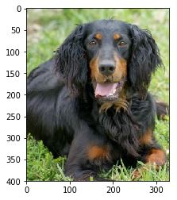

```
Dog raça: Gordon_setter
```

```python
detectar_raca_dogy(train_files[857])
```

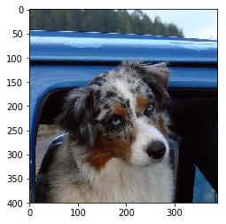

```
Dog raça: Australian_shepherd
10 None
```

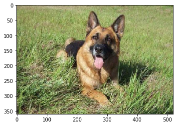

```
Dog raça: German_shepherd_dog
11 None
```

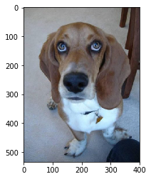

```
Dog raça: Basset_hound
12 None
```

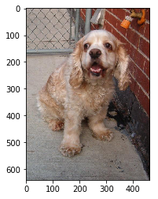

```
Dog raça: Cocker_spaniel
13 None
```

[figure not shown]

```
Dog raça: Lhasa_apso
14 None
```

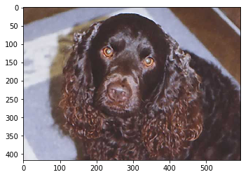

```
Dog raça: American_water_spaniel
15 None
```

[figure not shown]

```
Dog raça: Dachshund
16 None
```

[figure not shown]

```
Dog raça: Havanese
17 None
```

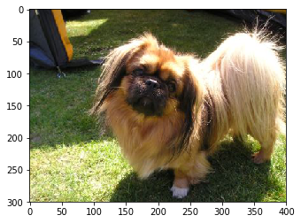

```
Dog raça: Pekingese
18 None
```

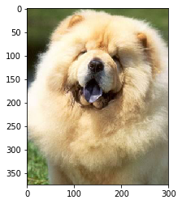

```
Dog raça: Chow_chow
19 None
```

```python
for p in range(10,20):
    print(p,dog_breed_detector(train_files[p]))
```

## Etapa 7: Teste seu algoritmo

Nesta seção, você levará seu novo algoritmo para dar uma volta! Que tipo de cão o algoritmo pensa que o **you** se parece? Se você tem um cachorro, ele prevê a raça do seu cão com precisão? Se você tem um gato, ele pensa erroneamente que seu gato é um cachorro?

### (IMPLEMENTATION) Teste seu algoritmo em imagens de exemplo!

Teste seu algoritmo com pelo menos seis imagens no seu computador. Sinta-se à vontade para usar qualquer imagem que desejar. Use pelo menos duas imagens humanas e duas de cachorro.

**Questão 6:** A saída é melhor do que você esperava :)? Ou pior: (? Fornecer pelo menos três possíveis pontos de melhoria para o seu algoritmo.

**Responda:**

```python
## Load the cell
from random import shuffle
sample_files = np.array(glob("sample_pictures/*"))
shuffle(sample_files)
print(sample_files)
```

```
['sample_pictures/human.jpg' 'sample_pictures/coquer.png'
 'sample_pictures/akita.jpeg' 'sample_pictures/husky.jpeg'
 'sample_pictures/rotweiler.jpeg' 'sample_pictures/trump.jpg']
```

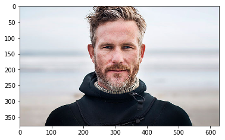

```
Humano: German_pinscher
```

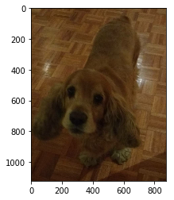

```
Dog raça: Golden_retriever
```

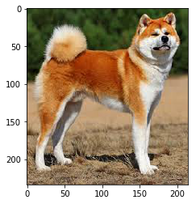

```
Dog raça: Akita
```

[figure not shown]

```
Dog raça: Alaskan_malamute
```

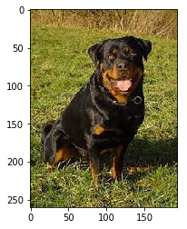

```
Dog raça: Beauceron
```

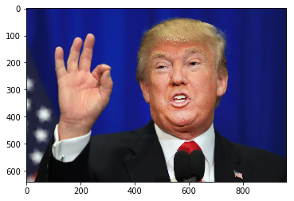

```
Humano: Silky_terrier
```

```python
for path in sample_files:
    dog_breed_detector(path)
```